# VoltageScript

## This is a script targeting giving a monitor of CMS pixel Phas I detector voltages, including portcard, modules, difference between them. I wrote this first part of script that we can collect information from everywehere– Hannsjorg’s spreadsheet of voltage recording, cable_map spreadsheet etc. Will asked me eight questions and I can now answer first one.

### 1) What is the voltage drop (Va, Vd) between the port card and the module?

2. What is the voltage drop between the DCDC converter and the Port Card? (In principle we know which DCDC converter went in which spot, but you can also measure, or get Hannsjoerg to measure, the output DCDC converter voltage for each DCDC converter)
3. Are the values measured in 1 and 2 consistent with our expectations? -For example: Is a low module voltage reading the result of a low port card voltage? -Is a low port card voltage the result of a broken wire between the DC DC converter and the port card, or is the DCDC converter having a problem?
4. I also don’t think the temperature measurement using the DCU has been sorted out yet. It would be good to follow up on this with Hannsjoerg.
5. I’m interested in this long term. I see us taking a read back calibration and measuring the DCU (and perhaps even getting a snapshot of the CAEN values) on a regular basis so we can see how the detector ages with time so we can keep it calibrated etc. During LS2 (where I imagine we will take the detector out) we will have another opportunity to measure values.
6. building a little on 6, we have been ignoring the CAEN eradicable voltages and currents, but we should have those values in the same spot as DCU and read back values so we can compare.
7. This will get more interesting as we get damage on the detector. The inner ROCS will see damage firs, and their read back conversions should change the fastest. The outer ROCs should change the least. I can imagine that at some point, we will use the outer ROC read back, and the fact that a module must be at the same voltage for all ROCs (barring problems with some ROCs), in order to track what happens with the detector.
8. It will also get interesting to see what happens during collisions. Knowing the CAEN voltages and currents and the port card voltages may be our best chance at knowing what the real power consumption is on the detector.

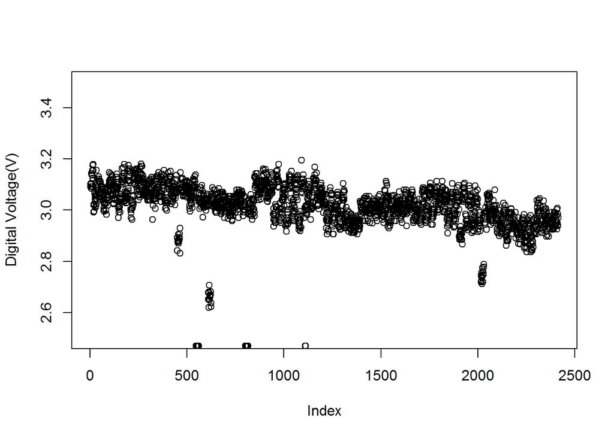

```r
backer<-read.table('Readbacker_1283.dat')
naming<-read.table('naming.dat')
colnames(naming)[2]="ROC ID"
colnames(naming)[1]="Official.name.of.position"
backer$V_Digi<-2*1.235*backer$V2/backer$V5
backer$V_Ana<-2*1.235*backer$V3/backer$V5
colnames(backer)[1]="ROC ID"
backer<-merge(backer, naming, by="ROC ID")
plot(backer$V_Digi, ylim = c(2.5, 3.5), ylab='Digital Voltage(V)')
```

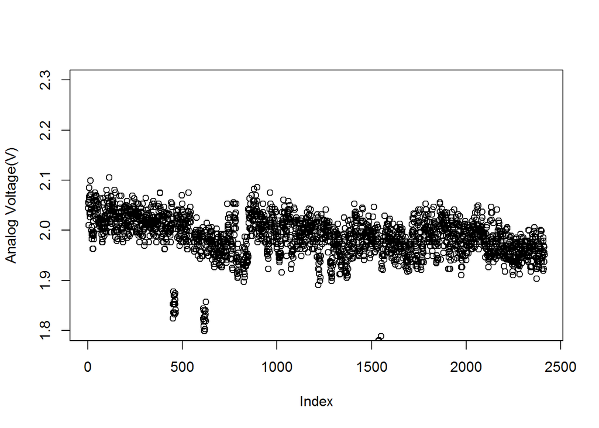

```r
plot(backer$V_Ana, ylim=c(1.8, 2.3), ylab='Analog Voltage(V)')
```

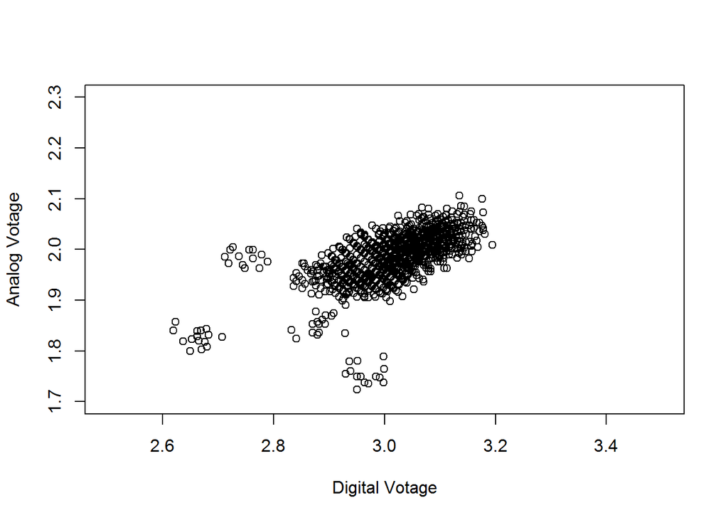

```r
plot(backer$V_Digi, backer$V_Ana, xlim=c(2.5, 3.5), ylim=c(1.7,2.3), xlab='Digital Votage', ylab='Analog Votage')
```

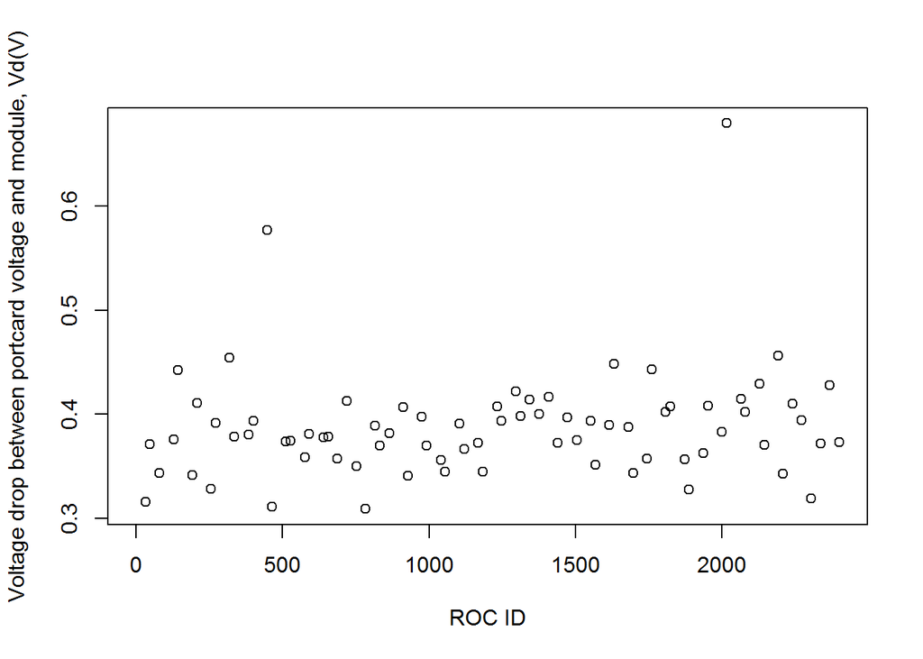

```r
Id=0.46
Ia=0.4

perfect_digi_Vd = 3.5- Id*(0.97/2) - (Id+Ia)*(0.97/6)
lost_digi_Vd = 3.5 - Id*(0.97) - (Id+Ia)*(0.97/6)



perfect_ana_Vd = 2.4 - Id*(0.97/2) - (Id+Ia)*(0.97/6)

lost_ana_Vd = 2.4 - Id*(0.97) - (Id+Ia)*(0.97/6)

outlier_digi<-backer[which(backer$V_Digi<=lost_digi_Vd),]
outlier_ana<-backer[which(backer$V_Ana<=lost_ana_Vd),]
#plot(outlier_ana$V_Ana, xlab='outlier analog voltage')
#plot(outlier_digi$`ROC ID`, ylab='outlier digital votage ROC ID', xlab='count')
outlier_both<-backer[which(backer$V_Ana<=lost_ana_Vd & backer$V_Digi<=lost_digi_Vd),]
Serious_wrong<-backer[which(backer$V2>500| backer$V3>500),]

####
backer$Official.name.of.position<- sapply(backer$Official.name.of.position, as.character)
###
cableName_BmI<-read.csv('Cabling Map for FPix Phase 1 Detector - BmI.csv')
cableName_BpI<-read.csv('Cabling Map for FPix Phase 1 Detector - BpI.csv')
cableName_BmO<-read.csv('Cabling Map for FPix Phase 1 Detector - BmO.csv')
cableName_BpO<-read.csv('Cabling Map for FPix Phase 1 Detector - BpO.csv')
DCU<-read.csv('DCU.csv')
light_BmO<-cableName_BmO[,c(1,8,9)]
light_BmO<-na.omit(light_BmO)
light_BmO$isOdd<-light_BmO$PC.port%%2

light_BpI<-cableName_BpI[,c(1,8,9)]
light_BpI<-na.omit(light_BpI)
light_BpI$isOdd<-light_BpI$PC.port%%2

light_BpO<-cableName_BpO[,c(1,8,9)]
light_BpO<-na.omit(light_BpO)
light_BpO$isOdd<-light_BpO$PC.port%%2
light_BpO$Official.name.of.position<-paste(light_BpO$Official.name.of.position, "_ROC0", sep="")


merged<-merge(backer, light_BpO, all=TRUE, by="Official.name.of.position")

####Deal with DCU table

BmI_DCU<-DCU[,c(1:4)]
BpO_DCU<-DCU[,c(1, 5:8)]
BpI_DCU<-DCU[,c(1,9:12)]
BmO_DCU<-DCU[,c(1,13:16)]

Cleaned_BmI_DCU_p1<-BmI_DCU[c(1:26),]
colnames(Cleaned_BmI_DCU_p1)<-c("PC.position.Mirror","direct meas(V)","DCU meas(V)", "input(V)")
Cleaned_BmI_DCU_p1<-Cleaned_BmI_DCU_p1[c(3:26),]

Cleaned_BmI_DCU_p2<-BmI_DCU[c(29:54),]
colnames(Cleaned_BmI_DCU_p2)<-c("PC.position.Mirror","Va1 direct meas(V)","Va1 DCU meas(V)", "Va1 input(V)")
Cleaned_BmI_DCU_p2<-Cleaned_BmI_DCU_p2[c(3:26),]


Cleaned_BmI_DCU_p3<-BmI_DCU[c(57:82),]
colnames(Cleaned_BmI_DCU_p3)<-c("PC.position.Mirror","Vd1 direct meas(V)","Vd1 DCU meas(V)", "Vd1 input(V)")
Cleaned_BmI_DCU_p3<-Cleaned_BmI_DCU_p3[c(3:26),]


Cleaned_BmI_DCU_p4<-BmI_DCU[c(85:110),]
colnames(Cleaned_BmI_DCU_p4)<-c("PC.position.Mirror","Va2 direct meas(V)","Va2 DCU meas(V)", "Va2 input(V)")
Cleaned_BmI_DCU_p4<-Cleaned_BmI_DCU_p4[c(3:26),]

Cleaned_BmI_DCU_p5<-BmI_DCU[c(113:138),]
colnames(Cleaned_BmI_DCU_p5)<-c("PC.position.Mirror","Vd2 direct meas(V)","Vd2 DCU meas(V)", "Vd2 input(V)")
Cleaned_BmI_DCU_p5<-Cleaned_BmI_DCU_p5[c(3:26),]

Cleanned_BmI_DCU<-merge(merge(merge(merge(Cleaned_BmI_DCU_p1, Cleaned_BmI_DCU_p2, by="PC.position.Mirror"), Cleaned_BmI_DCU_p3, by='PC.position.Mirror'), Cleaned_BmI_DCU_p4, by='PC.position.Mirror'), Cleaned_BmI_DCU_p5, by='PC.position.Mirror')

###DCU PbO##
Cleaned_BpO_DCU_p1<-BpO_DCU[c(1:26),]
BpO_name<-sapply(BpO_DCU[2,], as.character)

BpO_name[1]<-"PC.position.Mirror"
colnames(Cleaned_BpO_DCU_p1)<-BpO_name
Cleaned_BpO_DCU_p1<-Cleaned_BpO_DCU_p1[c(3:26),]

Cleaned_BpO_DCU_p2<-BpO_DCU[c(29:54),]
BpO_name<-sapply(BpO_DCU[2,], as.character)
BpO_name[1]<-"PC.position.Mirror"
BpO_name[2:5]<-paste('Va1',BpO_name[2:5])
colnames(Cleaned_BpO_DCU_p2)<-BpO_name
Cleaned_BpO_DCU_p2<-Cleaned_BpO_DCU_p2[c(3:26),]


Cleaned_BpO_DCU_p3<-BpO_DCU[c(57:82),]
BpO_name<-sapply(BpO_DCU[2,], as.character)
BpO_name[1]<-"PC.position.Mirror"
BpO_name[2:5]<-paste('Vd1',BpO_name[2:5])
colnames(Cleaned_BpO_DCU_p3)<-BpO_name
Cleaned_BpO_DCU_p3<-Cleaned_BpO_DCU_p3[c(3:26),]


Cleaned_BpO_DCU_p4<-BpO_DCU[c(85:110),]
BpO_name<-sapply(BpO_DCU[2,], as.character)
BpO_name[1]<-"PC.position.Mirror"
BpO_name[2:5]<-paste('Va2',BpO_name[2:5])
colnames(Cleaned_BpO_DCU_p4)<-BpO_name
Cleaned_BpO_DCU_p4<-Cleaned_BpO_DCU_p4[c(3:26),]

Cleaned_BpO_DCU_p5<-BpO_DCU[c(113:138),]
BpO_name<-sapply(BpO_DCU[2,], as.character)
BpO_name[1]<-"PC.position.Mirror"
BpO_name[2:5]<-paste('Vd2',BpO_name[2:5])
colnames(Cleaned_BpO_DCU_p5)<-BpO_name
Cleaned_BpO_DCU_p5<-Cleaned_BpO_DCU_p5[c(3:26),]

Cleanned_BpO_DCU<-merge(merge(merge(merge(Cleaned_BpO_DCU_p1, Cleaned_BpO_DCU_p2, by="PC.position.Mirror"), Cleaned_BpO_DCU_p3, by='PC.position.Mirror'), Cleaned_BpO_DCU_p4, by='PC.position.Mirror'), Cleaned_BpO_DCU_p5, by='PC.position.Mirror')


#BpI#

Cleaned_BpI_DCU_p1<-BpI_DCU[c(1:26),]
BpI_name<-sapply(BpI_DCU[2,], as.character)
BpI_name[1]<-"PC.position.Mirror"
colnames(Cleaned_BpI_DCU_p1)<-BpI_name
Cleaned_BpI_DCU_p1<-Cleaned_BpI_DCU_p1[c(3:26),]

Cleaned_BpI_DCU_p2<-BpI_DCU[c(29:54),]
BpI_name<-sapply(BpI_DCU[2,], as.character)
BpI_name[1]<-"PC.position.Mirror"
BpI_name[2:5]<-paste('Va1',BpI_name[2:5])
colnames(Cleaned_BpI_DCU_p2)<-BpI_name
Cleaned_BpI_DCU_p2<-Cleaned_BpI_DCU_p2[c(3:26),]


Cleaned_BpI_DCU_p3<-BpI_DCU[c(57:82),]
BpI_name<-sapply(BpI_DCU[2,], as.character)
BpI_name[1]<-"PC.position.Mirror"
BpI_name[2:5]<-paste('Vd1',BpI_name[2:5])
colnames(Cleaned_BpI_DCU_p3)<-BpI_name
Cleaned_BpI_DCU_p3<-Cleaned_BpI_DCU_p3[c(3:26),]


Cleaned_BpI_DCU_p4<-BpI_DCU[c(85:110),]
BpI_name<-sapply(BpI_DCU[2,], as.character)
BpI_name[1]<-"PC.position.Mirror"
BpI_name[2:5]<-paste('Va2',BpI_name[2:5])
colnames(Cleaned_BpI_DCU_p4)<-BpI_name
Cleaned_BpI_DCU_p4<-Cleaned_BpI_DCU_p4[c(3:26),]

Cleaned_BpI_DCU_p5<-BpI_DCU[c(113:138),]
BpI_name<-sapply(BpI_DCU[2,], as.character)
BpI_name[1]<-"PC.position.Mirror"
BpI_name[2:5]<-paste('Vd2',BpI_name[2:5])
colnames(Cleaned_BpI_DCU_p5)<-BpI_name
Cleaned_BpI_DCU_p5<-Cleaned_BpI_DCU_p5[c(3:26),]

Cleanned_BpI_DCU<-merge(merge(merge(merge(Cleaned_BpI_DCU_p1, Cleaned_BpI_DCU_p2, by="PC.position.Mirror"), Cleaned_BpI_DCU_p3, by='PC.position.Mirror'), Cleaned_BpI_DCU_p4, by='PC.position.Mirror'), Cleaned_BpI_DCU_p5, by='PC.position.Mirror')

#BmO##
Cleaned_BmO_DCU_p1<-BmO_DCU[c(1:26),]
BmO_name<-sapply(BmO_DCU[2,], as.character)
BmO_name[1]<-"PC.position.Mirror"
colnames(Cleaned_BmO_DCU_p1)<-BmO_name
Cleaned_BmO_DCU_p1<-Cleaned_BmO_DCU_p1[c(3:26),]

Cleaned_BmO_DCU_p2<-BmO_DCU[c(29:54),]
BmO_name<-sapply(BmO_DCU[2,], as.character)
BmO_name[1]<-"PC.position.Mirror"
BmO_name[2:5]<-paste('Va1',BmO_name[2:5])
colnames(Cleaned_BmO_DCU_p2)<-BmO_name
Cleaned_BmO_DCU_p2<-Cleaned_BmO_DCU_p2[c(3:26),]


Cleaned_BmO_DCU_p3<-BmO_DCU[c(57:82),]
BmO_name<-sapply(BmO_DCU[2,], as.character)
BmO_name[1]<-"PC.position.Mirror"
BmO_name[2:5]<-paste('Vd1',BmO_name[2:5])
colnames(Cleaned_BmO_DCU_p3)<-BmO_name
Cleaned_BmO_DCU_p3<-Cleaned_BmO_DCU_p3[c(3:26),]


Cleaned_BmO_DCU_p4<-BmO_DCU[c(85:110),]
BmO_name<-sapply(BmO_DCU[2,], as.character)
BmO_name[1]<-"PC.position.Mirror"
BmO_name[2:5]<-paste('Va2',BmO_name[2:5])
colnames(Cleaned_BmO_DCU_p4)<-BmO_name
Cleaned_BmO_DCU_p4<-Cleaned_BmO_DCU_p4[c(3:26),]

Cleaned_BmO_DCU_p5<-BmO_DCU[c(113:138),]
BmO_name<-sapply(BmO_DCU[2,], as.character)
BmO_name[1]<-"PC.position.Mirror"
BmO_name[2:5]<-paste('Vd2',BmO_name[2:5])
colnames(Cleaned_BmO_DCU_p5)<-BmO_name
Cleaned_BmO_DCU_p5<-Cleaned_BmO_DCU_p5[c(3:26),]

Cleanned_BmO_DCU<-merge(merge(merge(merge(Cleaned_BmO_DCU_p1, Cleaned_BmO_DCU_p2, by="PC.position.Mirror"), Cleaned_BmO_DCU_p3, by='PC.position.Mirror'), Cleaned_BmO_DCU_p4, by='PC.position.Mirror'), Cleaned_BmO_DCU_p5, by='PC.position.Mirror')


####
merged$PC.position.Mirror<-sapply(merged$PC.position.Mirror, as.character)
#print(merged$PC.position.Mirror)
for(i in 1:length(merged$PC.position.Mirror)) {
  if (!is.na(merged$PC.position.Mirror[i])) {
    a=merged$PC.position.Mirror[i]
    merged$PC.position.Mirror[i]<- paste(substr(a, start=2, stop=2), substr(a, start=1, stop=1), substr(a, start=3, stop = 3), sep="")
  }
}
#print(merged$PC.position.Mirror)
Cleanned_BpO_DCU$PC.position.Mirror<-sapply(Cleanned_BpO_DCU$PC.position.Mirror, as.character)
Everything<-merge(merged, Cleanned_BpO_DCU, by="PC.position.Mirror", all=TRUE)

##If PC.port is odd, then set Va1 Vd1 and Va_final Vd_final, otherwise set Va2 Vd2 as Va_final Vd_final
Everything<-Everything[1:168,]
Everything$`Va1 direct meas. (V)`<- as.numeric(levels(Everything$`Va1 direct meas. (V)`))[Everything$`Va1 direct meas. (V)`]
Everything$`Va2 direct meas. (V)`<-as.numeric(levels(Everything$`Va2 direct meas. (V)`))[Everything$`Va2 direct meas. (V)`]
for( i in 1:length(Everything$isOdd)){
  if(Everything$isOdd[i]){
    Everything$`Va_final direct meas. (V)`[i]<-Everything$`Va1 direct meas. (V)`[i]
  }
  else{
    Everything$`Va_final direct meas. (V)`[i]<-Everything$`Va2 direct meas. (V)`[i]
  }
}

##Same thing for non direct meas,
Everything$`Va1 DCU* meas. (V)`<-as.numeric(levels(Everything$`Va1 DCU* meas. (V)`))[Everything$`Va1 DCU* meas. (V)`]
Everything$`Va2 DCU* meas. (V)`<-as.numeric(levels(Everything$`Va2 DCU* meas. (V)`))[Everything$`Va1 DCU* meas. (V)`]
for( i in 1:length(Everything$isOdd)){
  if(Everything$isOdd[i]){
    Everything$`Va_final DCU* meas. (V)`[i] <-Everything$`Va1 DCU* meas. (V)`[i]
  }
  else{
    Everything$`Va_final DCU* meas. (V)`[i]<-Everything$`Va2 DCU* meas. (V)`[i]
  }
}

## same thing for digi
Everything<-Everything[1:168,]
Everything$`Vd1 direct meas. (V)` <- as.numeric(levels(Everything$`Vd1 direct meas. (V)`))[Everything$`Vd1 direct meas. (V)`]
Everything$`Vd2 direct meas. (V)` <-as.numeric(levels(Everything$`Vd2 direct meas. (V)`))[Everything$`Vd2 direct meas. (V)`]
for( i in 1:length(Everything$isOdd)){
  if(Everything$isOdd[i]){
    Everything$`Vd_final direct meas. (V)`[i]<-Everything$`Vd1 direct meas. (V)`[i]
  }
  else{
    Everything$`Vd_final direct meas. (V)`[i]<-Everything$`Vd2 direct meas. (V)`[i]
  }
}

Everything$`Vd1 DCU* meas. (V)`<-as.numeric(levels(Everything$`Vd1 DCU* meas. (V)`))[Everything$`Vd1 DCU* meas. (V)`]
Everything$`Vd2 DCU* meas. (V)`<-as.numeric(levels(Everything$`Vd2 DCU* meas. (V)`))[Everything$`Vd2 DCU* meas. (V)`]
for( i in 1:length(Everything$isOdd)){
  if(Everything$isOdd[i]){
    Everything$`Vd_final DCU* meas. (V)`[i] <-Everything$`Vd1 DCU* meas. (V)`[i]
  }
  else{
    Everything$`Vd_final DCU* meas. (V)`[i]<-Everything$`Vd2 DCU* meas. (V)`[i]
  }
}

##Plot difference answer Will's first question

Everything$`Diff_Vd_DCU* means. (V)`<-(Everything$`Vd_final DCU* meas. (V)`-Everything$V_Digi)
Everything$`Diff_Va_DCU* means. (V)`<-(Everything$`Va_final DCU* meas. (V)`-Everything$V_Ana)
write.table(Everything, file='everything.csv')
plot(Everything$`ROC ID`,Everything$`Diff_Vd_DCU* means. (V)`, xlab='ROC ID',ylab='Voltage drop between portcard voltage and module, Vd(V)')
```

```r
View(Everything)
```